# Labour Force Data Analysis 2

Amir Al Kowshik

October 30, 2023

```r
library(tidyverse)
library(modelr)
library(broom)
```

```r
LFS <- read_csv("pub0922.csv", guess_max = 10000)
FTEmployed <- LFS %>%

  # first, restrict the sample to individuals employed full time
  filter(LFSSTAT == 1 & FTPTMAIN == 1) %>%

  # now create the categorical education variable
  mutate(EduCat = if_else(EDUC == 0, "0 to 8 years", ""),
         EduCat = if_else(EDUC == 1, "Some high school", EduCat),
         EduCat = if_else(EDUC == 2, "High school graduate", EduCat),
         EduCat = if_else(EDUC == 3, "Some postsecondary", EduCat),
         EduCat = if_else(EDUC == 4, "Postsecondary certificate or diploma", EduCat),
         EduCat = if_else(EDUC == 5, "Bachelor's degree", EduCat),
         EduCat = if_else(EDUC == 6, "Above bachelor's degree", EduCat),

         # and the Wage variable
         Wage = HRLYEARN/100)
```

```r
out <- lm(Wage ~ TENURE + EduCat, data=FTEmployed)
summary(out)
```

```
##
## Call:
## lm(formula = Wage ~ TENURE + EduCat, data = FTEmployed)
##
## Residuals:
##     Min      1Q  Median      3Q     Max
## -45.847  -8.993  -2.584   6.611  83.009
##
## Coefficients:
##                                             Estimate Std. Error t value
## (Intercept)                                18.828209   0.607357  31.000
## TENURE                                      0.041650   0.000795  52.392
## EduCatAbove bachelor's degree              21.542447   0.634535  33.950
## EduCatBachelor's degree                    15.571656   0.618033  25.196
## EduCatHigh school graduate                  4.215650   0.622873   6.768
## EduCatPostsecondary certificate or diploma  8.608980   0.611595  14.076
## EduCatSome high school                      1.970906   0.677058   2.911
## EduCatSome postsecondary                    5.374532   0.685926   7.835
##                                            Pr(>|t|)
## (Intercept)                                 < 2e-16 ***
## TENURE                                      < 2e-16 ***
## EduCatAbove bachelor's degree               < 2e-16 ***
## EduCatBachelor's degree                     < 2e-16 ***
## EduCatHigh school graduate                 1.32e-11 ***
## EduCatPostsecondary certificate or diploma  < 2e-16 ***
## EduCatSome high school                       0.0036 **
## EduCatSome postsecondary                   4.78e-15 ***
## ---
## Signif. codes:  0 '***' 0.001 '**' 0.01 '*' 0.05 '.' 0.1 ' ' 1
##
## Residual standard error: 13.85 on 43013 degrees of freedom
##   (6290 observations deleted due to missingness)
## Multiple R-squared:  0.1931, Adjusted R-squared:  0.193
## F-statistic:  1471 on 7 and 43013 DF,  p-value: < 2.2e-16
```

Coefficients on categorical variables are measured relative to an omitted category. The omitted category is the one that doesn’t appear in the table of regression output. For `Educat`, the omitted category is “0 to 8 years” of education.

Let’s plot the coefficients on the education variables. To make it easier to read I’m reordering the categories from largest to smallest using `reorder`, and I’m replacing the characters “EduCat” with nothing (““) any time they appear in a value of the variable `term`.

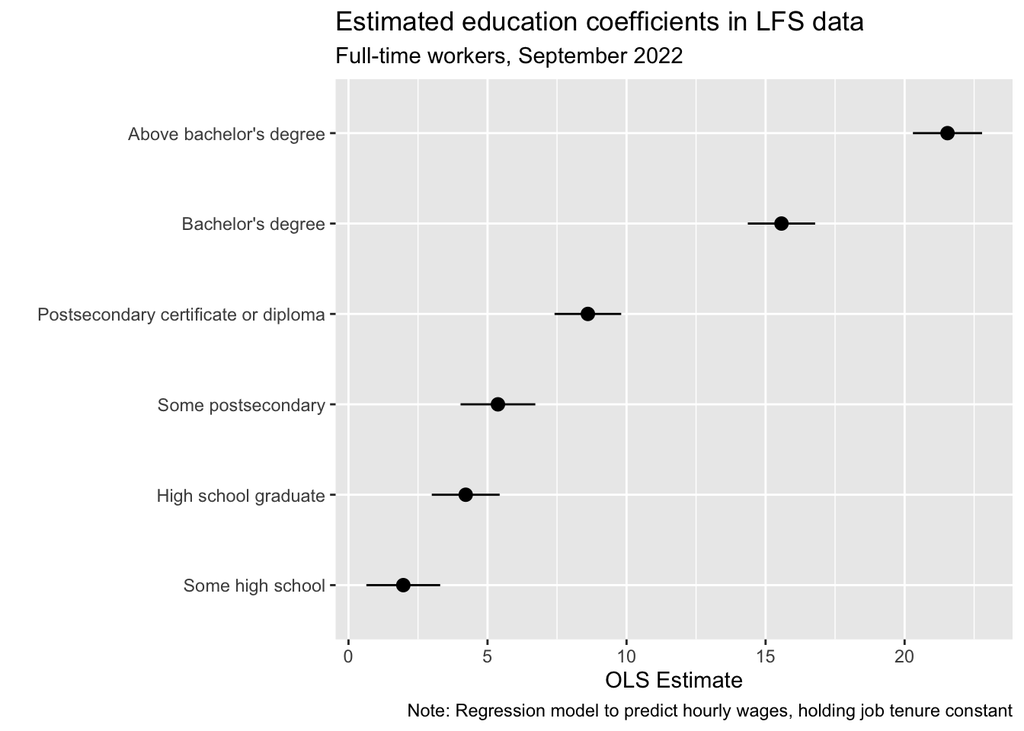

```r
p <- tidy(out, conf.int = TRUE) %>%
  filter(term != "TENURE", term != "(Intercept)") %>%
  mutate(term = gsub("EduCat", "", term)) %>%
  ggplot(aes(x = reorder(term, estimate), y = estimate, ymin = conf.low, ymax = conf.high))
p + geom_pointrange() + coord_flip() +
  labs(x="", y="OLS Estimate",
       title = "Estimated education coefficients in LFS data",
       subtitle = "Full-time workers, September 2022",
       caption = "Note: Regression model to predict hourly wages, holding job tenure constant")
```

None of the categorie’s confidence intervals include zero. In short, this tells us that we can be confident (i.e., with 95% probabilty) that individuals in each of these categories earn more, on average, than individuals in the reference category.

Now let’s create the requested immigration variable, and regress Wage on job tenure, education, and immigration status:

```r
FTEmployed <- FTEmployed %>%
  mutate(ImmigCat = if_else(IMMIG == 1, "Immigrant, landed 10 or less years earlier", ""),
         ImmigCat = if_else(IMMIG == 2, "Immigrant, landed more than 10 years earlier", ImmigCat),
         ImmigCat = if_else(IMMIG == 3, "Non-immigrant", ImmigCat))


out <- lm(Wage ~ TENURE + EduCat + ImmigCat, data=FTEmployed)
summary(out)
```

```
##
## Call:
## lm(formula = Wage ~ TENURE + EduCat + ImmigCat, data = FTEmployed)
##
## Residuals:
##     Min      1Q  Median      3Q     Max
## -46.585  -8.940  -2.596   6.566  82.528
##
## Coefficients:
##                                                       Estimate Std. Error
## (Intercept)                                          1.580e+01  6.455e-01
## TENURE                                               3.986e-02  8.043e-04
## EduCatAbove bachelor's degree                        2.188e+01  6.331e-01
## EduCatBachelor's degree                              1.561e+01  6.163e-01
## EduCatHigh school graduate                           3.938e+00  6.215e-01
## EduCatPostsecondary certificate or diploma           8.327e+00  6.102e-01
## EduCatSome high school                               1.627e+00  6.756e-01
## EduCatSome postsecondary                             5.038e+00  6.844e-01
## ImmigCatImmigrant, landed more than 10 years earlier 2.388e+00  3.003e-01
## ImmigCatNon-immigrant                                3.855e+00  2.602e-01
##                                                      t value Pr(>|t|)
## (Intercept)                                           24.478  < 2e-16 ***
## TENURE                                                49.560  < 2e-16 ***
## EduCatAbove bachelor's degree                         34.565  < 2e-16 ***
## EduCatBachelor's degree                               25.325  < 2e-16 ***
## EduCatHigh school graduate                             6.336 2.38e-10 ***
## EduCatPostsecondary certificate or diploma            13.645  < 2e-16 ***
## EduCatSome high school                                 2.409    0.016 *
## EduCatSome postsecondary                               7.361 1.86e-13 ***
## ImmigCatImmigrant, landed more than 10 years earlier   7.955 1.84e-15 ***
## ImmigCatNon-immigrant                                 14.818  < 2e-16 ***
## ---
## Signif. codes:  0 '***' 0.001 '**' 0.01 '*' 0.05 '.' 0.1 ' ' 1
##
## Residual standard error: 13.81 on 43011 degrees of freedom
##   (6290 observations deleted due to missingness)
## Multiple R-squared:  0.1978, Adjusted R-squared:  0.1977
## F-statistic:  1179 on 9 and 43011 DF,  p-value: < 2.2e-16
```

There’s a few different ways that we can visualize regression predctions with multiple predictor variables. Let’s start with the regression above, which includes all three variables but without any interactions. What that means is that the wage-tenure slope of the regression line is the same for all education and immigration categories, but the intercepts are different vary across these groups. We’ll see that when we do the plot. Let’s start by generating predictions on a tenure grid of 100 points between1 and 240, as well as all values of the EduCat and ImmigCat variables; then we’ll plot those predictions in a faceted scatter plot.

```r
# generate the predictions on a grid defined by tenure, education, and immigration status
grid <- FTEmployed %>%
  data_grid(TENURE = seq_range(TENURE,100),
            EduCat = c("0 to 8 years","Some high school", "High school graduate","Some postsecondary","Postsecondary certificate or diploma","Bachelor's degree","Above bachelor's degree"),
            ImmigCat = c("Immigrant, landed 10 or less years earlier","Immigrant, landed more than 10 years earlier","Non-immigrant"))
head(grid, n=10)
```

```
## # A tibble: 10 × 3
##    TENURE EduCat                  ImmigCat
##     <dbl> <chr>                   <chr>
##  1      1 0 to 8 years            Immigrant, landed 10 or less years earlier
##  2      1 0 to 8 years            Immigrant, landed more than 10 years earlier
##  3      1 0 to 8 years            Non-immigrant
##  4      1 Above bachelor's degree Immigrant, landed 10 or less years earlier
##  5      1 Above bachelor's degree Immigrant, landed more than 10 years earlier
##  6      1 Above bachelor's degree Non-immigrant
##  7      1 Bachelor's degree       Immigrant, landed 10 or less years earlier
##  8      1 Bachelor's degree       Immigrant, landed more than 10 years earlier
##  9      1 Bachelor's degree       Non-immigrant
## 10      1 High school graduate    Immigrant, landed 10 or less years earlier
```

```r
predictions <- cbind(grid,
                     predict(object = out, newdata = grid, interval = "confidence"))
head(predictions, n=10)
```

```
##    TENURE                  EduCat                                     ImmigCat
## 1       1            0 to 8 years   Immigrant, landed 10 or less years earlier
## 2       1            0 to 8 years Immigrant, landed more than 10 years earlier
## 3       1            0 to 8 years                                Non-immigrant
## 4       1 Above bachelor's degree   Immigrant, landed 10 or less years earlier
## 5       1 Above bachelor's degree Immigrant, landed more than 10 years earlier
## 6       1 Above bachelor's degree                                Non-immigrant
## 7       1       Bachelor's degree   Immigrant, landed 10 or less years earlier
## 8       1       Bachelor's degree Immigrant, landed more than 10 years earlier
## 9       1       Bachelor's degree                                Non-immigrant
## 10      1    High school graduate   Immigrant, landed 10 or less years earlier
##         fit      lwr      upr
## 1  15.83947 14.57446 17.10448
## 2  18.22793 17.00583 19.45003
## 3  19.69451 18.50260 20.88642
## 4  37.72360 37.15028 38.29691
## 5  40.11206 39.59738 40.62674
## 6  41.57864 41.13627 42.02101
## 7  31.44712 30.91987 31.97438
## 8  33.83559 33.40204 34.26913
## 9  35.30217 34.97395 35.63038
## 10 19.77717 19.20661 20.34773
```

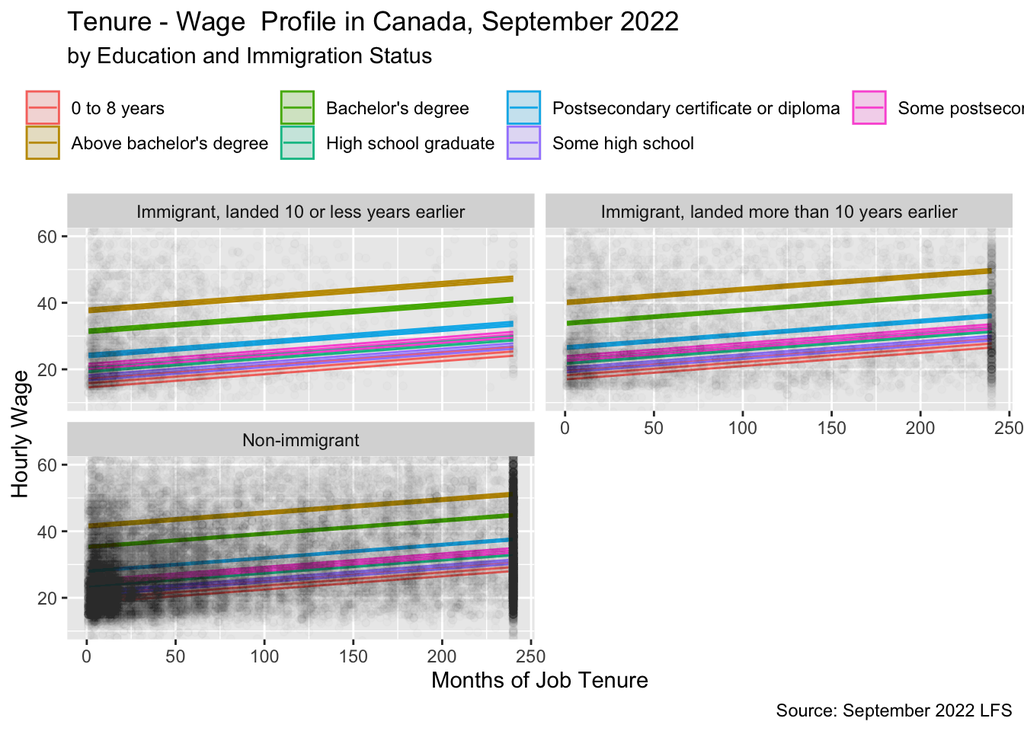

```r
# plot it!
p <- predictions %>%
  ggplot(mapping = aes(x = TENURE, y = fit, ymin = lwr, ymax = upr,
                       color = EduCat, fill = EduCat))

p + geom_line() +

  geom_ribbon(alpha = 0.2) +

  geom_point(data = FTEmployed,
             mapping = aes(x = TENURE, y = Wage),
             alpha = 0.01,
             inherit.aes = FALSE) +
  coord_cartesian(ylim = c(10,60)) +
  facet_wrap(  ~ ImmigCat, ncol = 2) +
  theme(legend.position = "top") +
  labs(title = "Tenure - Wage  Profile in Canada, September 2022",
       subtitle = "by Education and Immigration Status",
       caption = "Source: September 2022 LFS",
       x = "Months of Job Tenure",
       y = "Hourly Wage",
       color = "",
       fill = "")
```

One thing that becomes clear from this plot, but not from looking direclty at the output of `lm()` is that a lot of observations are piled up at `TENURE=240`! That’s just the value that gets recorded for everyone with 20+ years of job tenure. I would be worried that all that data piled up at one point might affect our regression estimates, so a good next step would be to re-estimate the model on the sample with `TENURE<240` only, to make sure that it doesn’t change our conclusions at all.